```r
library(tidyverse)
library(wbstats)
library(ggtext)
df <- readr::read_csv('https://raw.githubusercontent.com/rfordatascience/tidytuesday/master/data/2023/2023-08-22/population.csv')

options(scipen=999)
```

# Defining a scope

For this analysis, I’m going to focus on refugees. And I’m going to focus specifically on the countries from which refugees are fleeing – i.e., “Countries of Origin”, as well as the year 2022. For that reason, I’m going to drop a number columns from the dataset. I’m also going to drop some redundant location columns (`coo`, since I have `coo_iso`). Later I’ll add a filter for the year 2022.

This gives me a smaller set of data, and consequently, a narrower scope of questions that I can ask of it.

# Data cleaning

Something I had noticed about the dataset before filtering out many of the columns is that a COO could have multiple records in a year if refugees were leaving for different COAs. This means that I’ll want to group by COO and take a sum of refugees, even when looking at a specific year.

```r
df %>%
  filter(year == 2022) %>%
  # Need a group and sum here because COOs have multiple COAs per year
  group_by(coo_name) %>%
  # Convert refugees to refugees in units of millions
  summarize(refugees = sum(refugees)/1000000,
            coo_iso = first(coo_iso)) -> df_clean
```

# Data exploration

Next, I want to understand which Countries of Origin (COO) had the most refugees leaving in 2022.

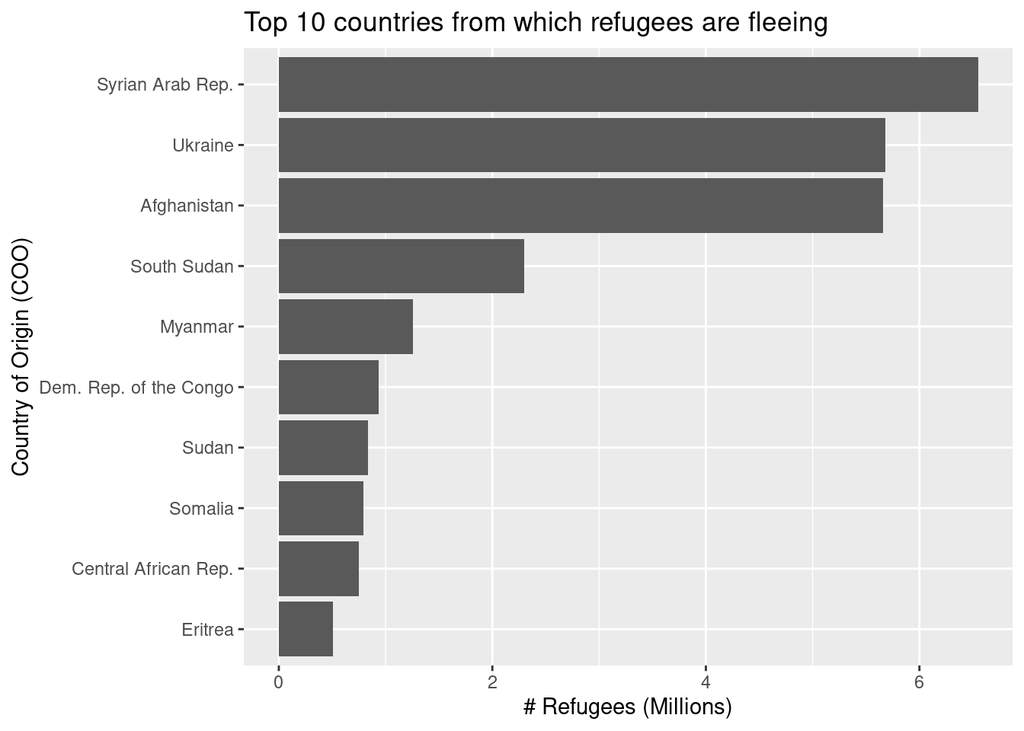

```r
df_clean %>%
  arrange(refugees) %>%
  slice_tail(n=10) %>%
  ggplot(aes(x=refugees, y=fct_inorder(coo_name))) +
    geom_bar(stat='identity') +
    ggtitle('Top 10 countries from which refugees are fleeing') +
    xlab('# Refugees (Millions)') +
    ylab('Country of Origin (COO)')
```

# Enriching the dataset

Next, I want to enrich the dataset with third-party data so I can add another dimension to the visualization: a country’s economic status. Specifically, I want to identify the “poorer” countries using GNI per capita. According to a [United Nations report from 2014](https://www.un.org/en/development/desa/policy/wesp/wesp_current/2014wesp_country_classification.pdf):

> Countries with less than $1,035 GNI per capita are classified as low-income countries, those with between $1,036 and $4,085 as lower middle income countries, those with between $4,086 and $12,615 as upper middle income countries, and those with incomes of more than $12,615 as high-income countries.

```r
wb_search("NY.GNP.PCAP.KD", fields='indicator_id')
```

```
## # A tibble: 2 × 3
##   indicator_id      indicator                          indicator_desc
##   <chr>             <chr>                              <chr>
## 1 NY.GNP.PCAP.KD    GNI per capita (constant 2010 US$) GNI per capita is gross …
## 2 NY.GNP.PCAP.KD.ZG GNI per capita growth (annual %)   Annual percentage growth…
```

I’ll fetch more than just 2022 data, because this will give me more flexibility to impute values if they are missing for 2022 specifically: For each COO, I can just take the most recent GNI per capita value.

```r
gni_per_capita <- wb_data("NY.GNP.PCAP.CD", start_date = 2000, end_date = 2022) %>%
  select(iso3c, date, "NY.GNP.PCAP.CD") %>%
  rename(gni_per_capita = "NY.GNP.PCAP.CD",
         iso = iso3c)

df_clean %>%
  left_join(gni_per_capita, by=c('coo_iso'='iso')) -> df_enriched
```

```r
df_enriched %>%
  group_by(coo_name) %>%
  # In case of multiple records, take most recent
  summarize(gni_per_capita = last(gni_per_capita, order_by = date, na_rm = T)) %>%
  ungroup() %>%
  summarize(n = n(),
            n_missing = sum(is.na(gni_per_capita)),
            pct_missing = sum(is.na(gni_per_capita))/n()*100)
```

```
## # A tibble: 1 × 3
##       n n_missing pct_missing
##   <int>     <int>       <dbl>
## 1   205        11        5.37
```

I will create a new dataframe that again collapses across the years, taking the most recent GNI per capita, and then classifying the nation.

```r
df_enriched %>%
  group_by(coo_name) %>%
  summarize(gni_per_capita = last(gni_per_capita, order_by = date, na_rm = T),
            refugees = first(refugees)) %>%
  mutate(gni_class = case_when(gni_per_capita <= 1035 ~ 'low income',
                               gni_per_capita > 1035 & gni_per_capita < 4035 ~ 'lower income',
                               .default = 'unknown or not low/lower')) %>%
  select(coo_name, gni_class, gni_per_capita, refugees) -> df_enriched
```

# New data visualization

With the GNI income classifications ready, I can regenerate the visualization and colour the bars to represent nations that have been classified as low or lower income. I will also make the title more specific to the point that I’m trying to make with the visualization, and add a caption to provide context about what the classifications represent.

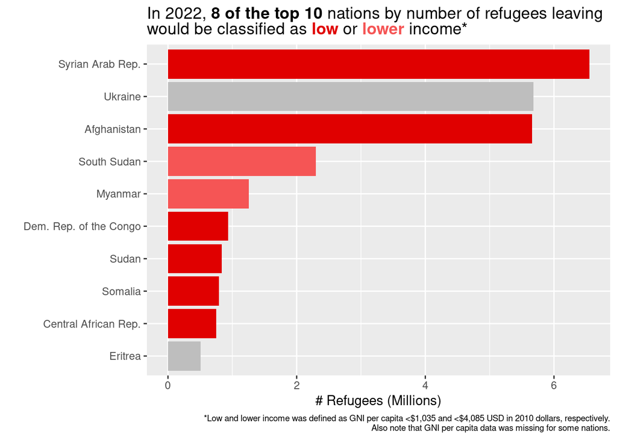

```r
df_enriched %>%
  arrange(refugees) %>%
  slice_tail(n=10) %>%
  ggplot(aes(x=refugees, y=fct_inorder(coo_name), fill=gni_class)) +
    geom_bar(stat='identity', show.legend = FALSE) +
    ggtitle("In 2022, <strong>8 of the top 10</strong> nations by number of refugees leaving<br>would be classified as <span style='color: #e00000'><strong>low</span></strong> or <span style='color: #f55555'><strong>lower</span></strong> income*") +
    xlab('# Refugees (Millions)') +
    ylab('')+
    scale_fill_manual(values=c("#e00000",
                               "#f55555",
                               "grey")) +
    labs(caption = "<span style='font-size:7pt'>*Low and lower income was defined as GNI per capita <$1,035 and <$4,085 USD in 2010 dollars, respectively.<br>Also note that GNI per capita data was missing for some nations.</span>") +
    theme(plot.title = element_markdown(),
          plot.caption = element_markdown())
```